# ANÁLISE DE SOBREVIVÊNCIA

ANTÔNIO VICTOR ALVES SILVA

# INTRODUÇÃO

### Irá ser feito uma análise de sobrevivência no jogo overwatch, ressalto que o banco de dados apresenta muitos dados faltantes e que não foi possível análisar a maioria das variáveis por conta disso.

### Recomendo no futuro a tentativa de adquirir outro banco de dados para uma análise mais profunda, pois ela fere e muito os princípios estatísticos de aleatóriedade, assim, não conseguindo modelar os NAs e salvar os dados.

# PACOTES UTILIZADOS

```r
library(tidyverse)
library(ggthemes)
library(RColorBrewer)
library(survival)
library(survminer)
library(ggfortify)
library(skimr)
library(gridExtra)
library(ggridges)
library(readr)
```

# BANCO DE DADOS

```r
dados <- read_csv("overwatch_competitions_data_clear.csv")

colnames(dados)[33] <- 'character_1'
dados$X <- NULL

dados$dateTS <- as.Date(dados$date, format="%m/%d/%Y")
dados$year <- lubridate::year(dados$dateTS)
dados$month <- lubridate::month(dados$dateTS)
dados$dateTS2 <- as.Date(paste0(dados$year,'-',dados$month,'-01'))

dados$round <- sapply(dados$round, function(x) ifelse(grepl("-", x) || x =="",NA, as.numeric(x)))
dados$score_distance <- sapply(dados$score_distance, function(x) ifelse((grepl("-", x) || (x =="")) || grepl("^[A-Za-z]+$", x) , NA, as.numeric(x)))


dados$match_length <- as.numeric(dados$match_length, na.omit= T)
dados$time_left <- as.numeric(dados$time_left)

dados$psychological_condition <- ifelse(dados$psychological_condition =="",NA, dados$psychological_condition)
dados$communication <- ifelse((dados$communication %in% c("","-")),NA, dados$communication)
dados$team_role <- ifelse((dados$team_role %in% c("","w")),NA, dados$team_role)
dados$result <- ifelse(dados$result == "", NA, dados$result)

dados <- dados %>%
    mutate(sr_start = as.numeric(sr_start),
           sr_finish = as.numeric(sr_finish),
           sr_delta = as.numeric(sr_delta),
           streak_number = as.numeric(streak_number),
           my_team_sr = as.numeric(my_team_sr),
           enemy_team_sr = as.numeric(enemy_team_sr),
           team_sr_delta = as.numeric(team_sr_delta))
dados <- dados %>% filter(dateTS2 > "2016-01-24" & match_length < 50 & sr_delta<100)

dados
```

```
## # A tibble: 1,515 × 51
##     ...1 date       time  season game_id sr_start sr_fi…¹ sr_de…² strea…³ result
##    <dbl> <chr>      <chr>  <dbl>   <dbl>    <dbl>   <dbl>   <dbl>   <dbl> <chr>
##  1     1 12/4/2016  <NA>       3       2     2387    2367     -20      NA loss
##  2     3 12/4/2016  <NA>       3       3     2367    2367       0      NA <NA>
##  3     4 12/15/2016 <NA>       3       4     2367    2367       0      NA <NA>
##  4     5 12/15/2016 <NA>       3       5     2367    2330     -37      NA loss
##  5    11 12/6/2016  <NA>       3       8     2350    2331     -19      NA loss
##  6    13 12/6/2016  <NA>       3       9     2331    2331       0      NA draw
##  7    16 12/6/2016  <NA>       3      10     2331    2376      45      NA win
##  8    18 12/6/2016  <NA>       3      11     2376    2419      43      NA win
##  9    19 12/6/2016  <NA>       3      12     2419    2419       0      NA draw
## 10    25 12/6/2016  <NA>       3      13     2419    2454      35      NA win
## # … with 1,505 more rows, 41 more variables: my_team_sr <dbl>,
## #   enemy_team_sr <dbl>, team_sr_delta <dbl>, my_team_1 <chr>, my_team_2 <chr>,
## #   my_team_3 <chr>, my_team_4 <chr>, my_team_5 <chr>, my_team_6 <chr>,
## #   enemy_team_1 <chr>, enemy_team_2 <chr>, enemy_team_3 <chr>,
## #   enemy_team_4 <chr>, enemy_team_5 <chr>, enemy_team_6 <chr>, map <chr>,
## #   round <dbl>, capscore <chr>, score_distance <dbl>, time_left <dbl>,
## #   team_role <chr>, match_length <dbl>, character_1 <chr>, …
```

# DADOS FALTANTES

```r
round(mean(is.na(dados))*100,10)
```

```
## [1] 28.32071
```

28,32% dos dados são faltantes, mais na frente quando forem utilizados, será feito algo a respeito.

# VARIÁVEIS QUE SERÃO UTILIZADAS

### *match_length = duração na partida (Variável principal)*

### **result = resultado:**

### *win = vencer*

### *loss = perder*

### *draw = empate*

### character_1 = Personagem do game ( Contém mais duas colunas, porém muitos dados faltantes, irá ser analisado somente este)

### **team_role = papel da equipe:**

### *attack = ofensiva/ataque*

### *cp = meio termo*

### *defend = defensiva*

### year = ano

### month = mês

```r
dados <- rename(dados, sobrevivência = match_length)
dados <- rename(dados, resultado = result)
dados <- rename(dados,Pontuação_do_time_aliado =  my_team_sr )
dados <- rename(dados,Pontuação_do_time_adversário =  enemy_team_sr )
dados <- rename(dados,personagens = character_1)
round(mean(is.na(dados$character_2))*100,10) # muitos dados faltantes
```

```
## [1] 79.27393
```

```r
round(mean(is.na(dados$character_3))*100,10) # muitos dados faltantes
```

```
## [1] 97.29373
```

```r
dados <- rename(dados, papel_da_equipe =  team_role )
dados <- rename(dados, ano =  year )
dados <- rename(dados, mês =  month )
dados <- rename(dados, condição_psicológica = psychological_condition)
```

# RESULTADO DAS PARTIDAS

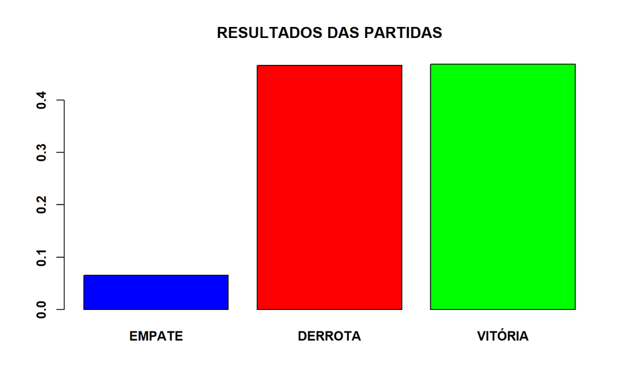

```r
 barplot(prop.table(table(dados$resultado)), names.arg=c("EMPATE", "DERROTA", "VITÓRIA"), col=c("BLUE","red", "GREEN"), main = "RESULTADOS DAS PARTIDAS", font.axis=2)
```

```r
 table (dados$resultado)
```

```
##
## draw loss  win
##   98  702  706
```

### NOTE QUE OS DADOS DE EMPATE SÃO POUCOS EM RELAÇÃO AS VARIÁVEIS VITÓRIA E DERROTA.

# SOBREVIVÊNCIA POR RESULTADO

```r
round(mean(is.na( dados$resultado))*100,10)
```

```
## [1] 0.5940594
```

```r
print(dados$resultado, max = 100)
```

```
##   [1] "loss" NA     NA     "loss" "loss" "draw" "win"  "win"  "draw" "win"
##  [11] "win"  "win"  "win"  "loss" "loss" "win"  "loss" "loss" "loss" "win"
##  [21] "win"  "loss" "win"  "win"  "loss" "win"  "loss" "draw" "loss" "win"
##  [31] "win"  "win"  "loss" "loss" "win"  "win"  "draw" "win"  "win"  "win"
##  [41] "loss" "loss" "loss" "loss" "loss" "loss" "loss" "win"  "win"  "loss"
##  [51] "draw" "loss" "loss" "win"  "loss" "loss" "loss" "draw" "win"  "win"
##  [61] "win"  "loss" "loss" "loss" "draw" "loss" "loss" "win"  "win"  "win"
##  [71] "win"  "loss" "loss" "win"  "loss" "win"  "win"  "loss" "win"  "loss"
##  [81] "win"  "win"  "loss" "win"  "win"  "loss" "win"  "loss" "win"  "draw"
##  [91] "loss" "loss" "win"  "win"  "loss" "loss" "win"  "win"  "loss" "loss"
##  [ reached getOption("max.print") -- omitted 1415 entries ]
```

### Analisando os dados faltantes, se nota que foi ferido o principio de aleatóriedade, pois faltam perante sequência. Então a melhor escolha seria deletar as linhas com NA.

#### No caso, todas feriram esse princípio, então será feito isso em todas variáveis analisadas.

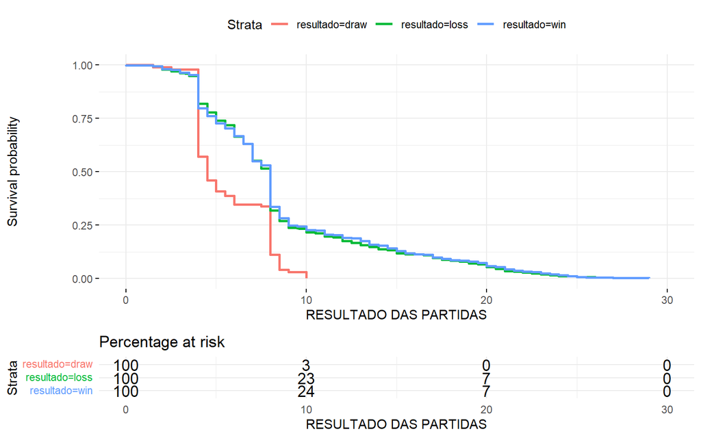

```r
p1 <- survfit(Surv(dados$sobrevivência) ~ dados$resultado, data=dados %>% filter(!is.na(resultado)))


 ggsurvplot(p1, data = dados, xlab="RESULTADO DAS PARTIDAS", ggtheme=theme_minimal(), risk.table = "percentage")
```

### Note que as partidas que o resultado é de empate são as que menos duram, isso é intrigante, pois empate significa mais tempo de partida, mas o resultado mostra diferente. Isso pode ter sido ocasionado por os dados de “empate” serem pequenos ou até mesmo problemas no banco de dados.

```r
summary (p1)
```

```
## Call: survfit(formula = Surv(dados$sobrevivência) ~ dados$resultado,
##     data = dados %>% filter(!is.na(resultado)))
##
## 9 observations deleted due to missingness
##                 dados$resultado=draw
##  time n.risk n.event survival std.err lower 95% CI upper 95% CI
##   1.5     98       1   0.9898  0.0102       0.9701       1.0000
##   2.5     97       1   0.9796  0.0143       0.9520       1.0000
##   4.0     96      40   0.5714  0.0500       0.4814       0.6783
##   4.5     56      11   0.4592  0.0503       0.3704       0.5692
##   5.0     45       5   0.4082  0.0496       0.3216       0.5181
##   5.5     40       2   0.3878  0.0492       0.3024       0.4973
##   6.0     38       4   0.3469  0.0481       0.2644       0.4552
##   7.5     34       1   0.3367  0.0477       0.2550       0.4446
##   8.0     33      22   0.1122  0.0319       0.0643       0.1959
##   8.5     11       7   0.0408  0.0200       0.0156       0.1066
##   9.0      4       1   0.0306  0.0174       0.0100       0.0933
##  10.0      3       3   0.0000     NaN           NA           NA
##
##                 dados$resultado=loss
##   time n.risk n.event survival std.err lower 95% CI upper 95% CI
##   0.00    702       1  0.99858 0.00142     0.995789       1.0000
##   1.00    701       1  0.99715 0.00201     0.993216       1.0000
##   1.50    700       2  0.99430 0.00284     0.988750       0.9999
##   2.00    698      11  0.97863 0.00546     0.967994       0.9894
##   2.50    687       6  0.97009 0.00643     0.957565       0.9828
##   3.00    681       6  0.96154 0.00726     0.947417       0.9759
##   3.30    675       1  0.96011 0.00739     0.945746       0.9747
##   3.50    674       8  0.94872 0.00832     0.932541       0.9652
##   4.00    666      92  0.81766 0.01457     0.789594       0.8467
##   4.50    574      28  0.77778 0.01569     0.747624       0.8091
##   5.00    546      27  0.73932 0.01657     0.707544       0.7725
##   5.50    519      15  0.71795 0.01698     0.685420       0.7520
##   6.00    504      38  0.66382 0.01783     0.629776       0.6997
##   6.50    466      23  0.63105 0.01821     0.596351       0.6678
##   7.00    443      56  0.55128 0.01877     0.515691       0.5893
##   7.50    387      26  0.51425 0.01886     0.478571       0.5526
##   8.00    361     138  0.31766 0.01757     0.285025       0.3540
##   8.50    223      34  0.26923 0.01674     0.238339       0.3041
##   9.00    189      22  0.23789 0.01607     0.208390       0.2716
```

[output cut: 77 more lines]

```
##  20.0     51      10  0.05807 0.00880      0.04315       0.0782
##  20.5     41       3  0.05382 0.00849      0.03951       0.0733
##  21.0     38       8  0.04249 0.00759      0.02994       0.0603
##  21.5     30       4  0.03683 0.00709      0.02525       0.0537
##  22.0     26       4  0.03116 0.00654      0.02065       0.0470
##  22.5     22       1  0.02975 0.00639      0.01952       0.0453
##  23.0     21       4  0.02408 0.00577      0.01506       0.0385
##  23.5     17       3  0.01983 0.00525      0.01181       0.0333
##  24.0     14       3  0.01558 0.00466      0.00867       0.0280
##  24.5     11       3  0.01133 0.00398      0.00569       0.0226
##  25.0      8       3  0.00708 0.00316      0.00296       0.0170
##  25.5      5       2  0.00425 0.00245      0.00137       0.0131
##  27.0      3       1  0.00283 0.00200      0.00071       0.0113
##  27.5      2       1  0.00142 0.00142      0.00020       0.0100
##  29.0      1       1  0.00000     NaN           NA           NA
```

### teste de log rank:

```r
surv_diff <- survdiff(Surv(dados$sobrevivência) ~ dados$resultado, data = dados)
surv_diff
```

```
## Call:
## survdiff(formula = Surv(dados$sobrevivência) ~ dados$resultado,
##     data = dados)
##
## n=1506, 9 observations deleted due to missingness.
##
##                        N Observed Expected (O-E)^2/E (O-E)^2/V
## dados$resultado=draw  98       98     52.9     38.56    49.200
## dados$resultado=loss 702      702    714.0      0.20     0.453
## dados$resultado=win  706      706    739.2      1.49     3.483
##
##  Chisq= 49.6  on 2 degrees of freedom, p= 2e-11
```

Menor que 0.05, logo tem diferença significativa pelo teste de log rank.

# PAPEL DA EQUIPE

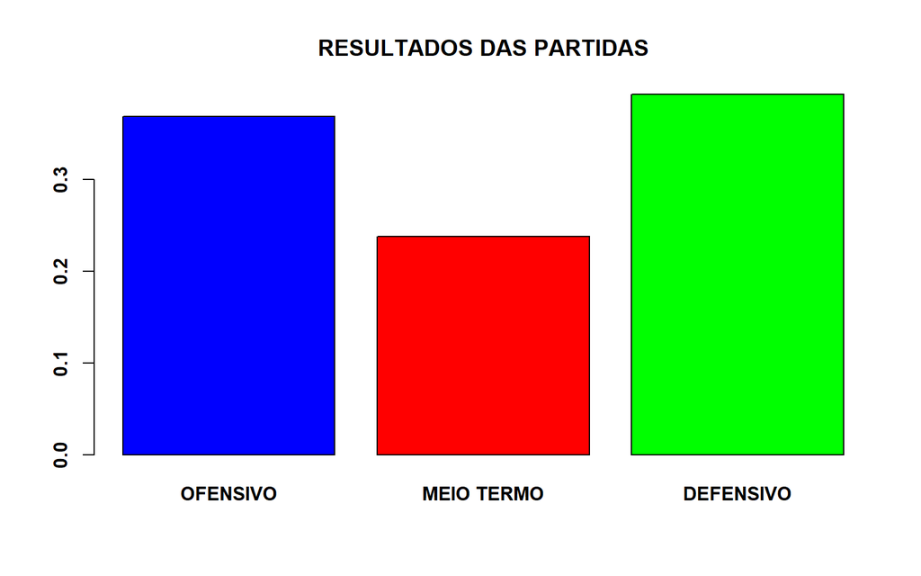

```r
 barplot(prop.table(table(dados$papel_da_equipe)), names.arg=c("OFENSIVO", "MEIO TERMO", "DEFENSIVO"), col=c("BLUE","red", "GREEN"), main = "RESULTADOS DAS PARTIDAS", font.axis=2)
```

```r
 table (dados$papel_da_equipe)
```

```
##
## attack     cp defend
##    557    360    594
```

### Note que aqui os dados estão mais bem distribuidos.

# SOBREVIVÊNCIA POR PAPEL DA EQUIPE

```r
round(mean(is.na( dados$papel_da_equipe))*100,10)
```

```
## [1] 0.2640264
```

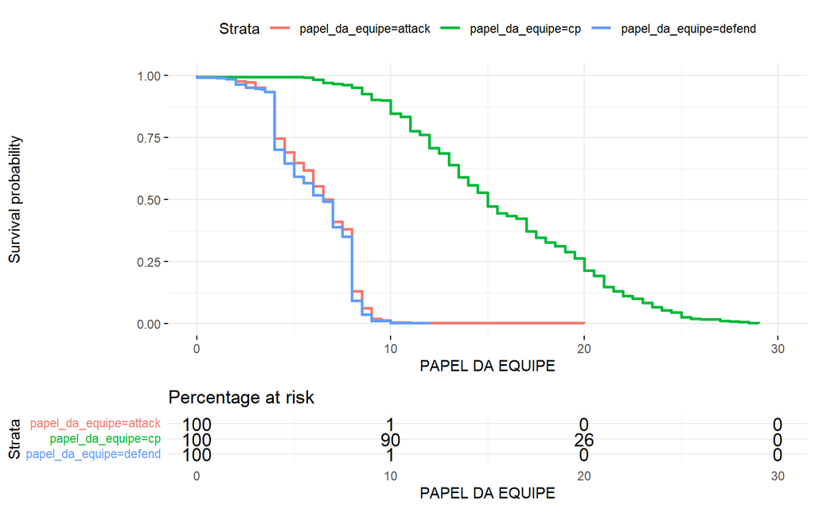

```r
pe <- survfit(Surv(dados$sobrevivência) ~ dados$papel_da_equipe, data=dados %>% filter(!is.na(papel_da_equipe)))


 ggsurvplot(pe, data = dados, xlab="PAPEL DA EQUIPE", ggtheme=theme_minimal(), risk.table = "percentage")
```

### As equipes “meio termo” são as que duram mais tempo nas partidas.

```r
summary (pe)
```

```
## Call: survfit(formula = Surv(dados$sobrevivência) ~ dados$papel_da_equipe,
##     data = dados %>% filter(!is.na(papel_da_equipe)))
##
## 4 observations deleted due to missingness
##                 dados$papel_da_equipe=attack
##   time n.risk n.event survival std.err lower 95% CI upper 95% CI
##   0.00    557       3  0.99461 0.00310     0.988554       1.0000
##   1.50    554       2  0.99102 0.00400     0.983221       0.9989
##   2.00    552       8  0.97666 0.00640     0.964203       0.9893
##   2.50    544       3  0.97127 0.00708     0.957502       0.9852
##   3.00    541      11  0.95153 0.00910     0.933857       0.9695
##   3.50    530      10  0.93357 0.01055     0.913119       0.9545
##   4.00    520     104  0.74686 0.01842     0.711608       0.7839
##   4.50    416      31  0.69120 0.01958     0.653881       0.7307
##   5.00    385      24  0.64811 0.02023     0.609644       0.6890
##   5.50    361      17  0.61759 0.02059     0.578526       0.6593
##   6.00    344      36  0.55296 0.02107     0.513177       0.5958
##   6.50    308      29  0.50090 0.02119     0.461049       0.5442
##   7.00    279      51  0.40934 0.02083     0.370472       0.4523
##   7.50    228      16  0.38061 0.02057     0.342351       0.4231
##   8.00    212     139  0.13106 0.01430     0.105828       0.1623
##   8.50     73      38  0.06284 0.01028     0.045596       0.0866
##   9.00     35      24  0.01975 0.00590     0.011001       0.0355
##   9.50     11       3  0.01436 0.00504     0.007219       0.0286
##   9.58      8       1  0.01257 0.00472     0.006019       0.0262
##  10.00      7       4  0.00539 0.00310     0.001742       0.0166
##  11.00      3       2  0.00180 0.00179     0.000253       0.0127
##  20.00      1       1  0.00000     NaN           NA           NA
##
##                 dados$papel_da_equipe=cp
##  time n.risk n.event survival std.err lower 95% CI upper 95% CI
##   0.0    360       2  0.99444 0.00392     0.986796       1.0000
##   5.5    358       1  0.99167 0.00479     0.982320       1.0000
##   6.0    357       3  0.98333 0.00675     0.970198       0.9966
##   6.5    354       5  0.96944 0.00907     0.951828       0.9874
##   7.0    349       1  0.96667 0.00946     0.948301       0.9854
##   7.5    348       2  0.96111 0.01019     0.941346       0.9813
##   8.0    346       4  0.95000 0.01149     0.927751       0.9728
##   8.5    342       9  0.92500 0.01388     0.898188       0.9526
##   9.0    333       8  0.90278 0.01561     0.872687       0.9339
```

[output cut: 49 more lines]

```
##   3.5    561       6  0.93434 0.01016     0.914636       0.9545
##   4.0    555     139  0.70034 0.01880     0.664448       0.7382
##   4.5    416      33  0.64478 0.01964     0.607421       0.6844
##   5.0    383      32  0.59091 0.02017     0.552664       0.6318
##   5.5    351      15  0.56566 0.02034     0.527168       0.6070
##   6.0    336      29  0.51684 0.02050     0.478171       0.5586
##   6.5    307      15  0.49158 0.02051     0.452979       0.5335
##   7.0    292      61  0.38889 0.02000     0.351596       0.4301
##   7.5    231      23  0.35017 0.01957     0.313834       0.3907
##   8.0    208     154  0.09091 0.01180     0.070496       0.1172
##   8.5     54      32  0.03704 0.00775     0.024578       0.0558
##   9.0     22      15  0.01178 0.00443     0.005643       0.0246
##   9.5      7       1  0.01010 0.00410     0.004556       0.0224
##  10.0      6       5  0.00168 0.00168     0.000238       0.0119
##  12.0      1       1  0.00000     NaN           NA           NA
```

### teste de log rank:

```r
surv_diff <- survdiff(Surv(dados$sobrevivência) ~ dados$papel_da_equipe, data = dados)
surv_diff
```

```
## Call:
## survdiff(formula = Surv(dados$sobrevivência) ~ dados$papel_da_equipe,
##     data = dados)
##
## n=1511, 4 observations deleted due to missingness.
##
##                                N Observed Expected (O-E)^2/E (O-E)^2/V
## dados$papel_da_equipe=attack 557      557      355       116       204
## dados$papel_da_equipe=cp     360      360      801       243       938
## dados$papel_da_equipe=defend 594      594      355       161       288
##
##  Chisq= 942  on 2 degrees of freedom, p= <2e-16
```

Menor que 0.05, logo tem diferença significativa pelo teste de log rank.

# PERSONAGENS

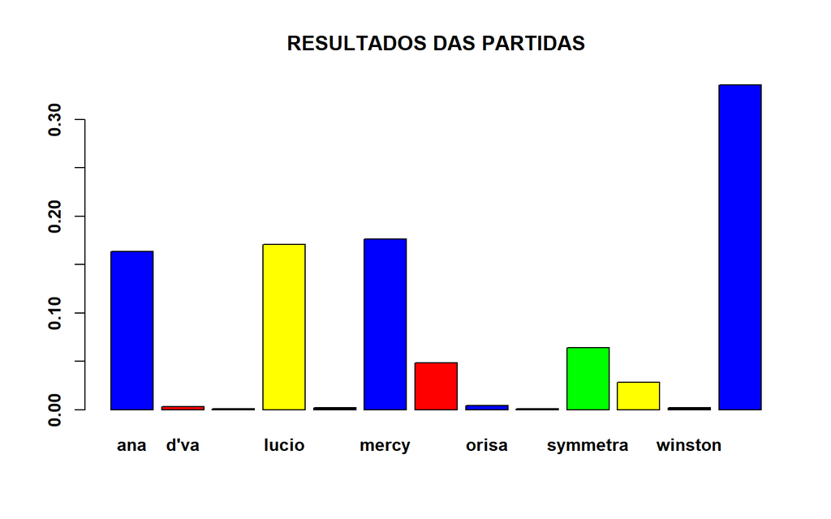

```r
 barplot(prop.table(table(dados$personagens)), col=c("BLUE","red", "GREEN", "yellow", "black", "blue", "red"), main = "RESULTADOS DAS PARTIDAS", font.axis=2)
```

```r
 table (dados$personagens)
```

```
##
##      ana     d'va    error    lucio    luico    mercy    moira    orisa
##      239        5        1      250        3      258       71        6
## rienhart symmetra torbjorn  winston      zen
##        1       94       41        3      491
```

### Note que os dados não estão bem distribuidos, tem variáveis que tem quase nada de informação e algumas que tem muitas.

### Perante esse impasse, recomendo outro banco de dados para fazer a análise somente desse caso.

```r
dadosdepersonagens <-  dados %>% filter(personagens == c("ana", "lucio", "mercy", "zen"))
```

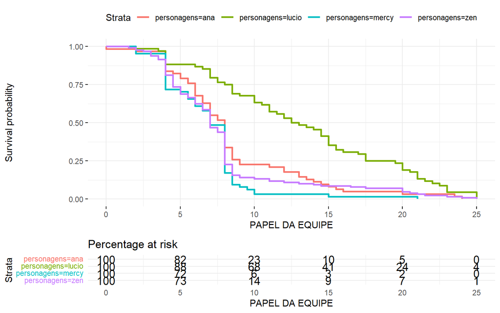

```r
dadosdepersonagens$sobrevivência <- na.omit (dadosdepersonagens$sobrevivência)

po <- survfit(Surv(dadosdepersonagens$sobrevivência) ~ dadosdepersonagens$personagens, data=dadosdepersonagens %>% filter(!is.na(dadosdepersonagens$personagens)))


 ggsurvplot(po, data = dadosdepersonagens, xlab="PAPEL DA EQUIPE", ggtheme=theme_minimal(), risk.table = "percentage")
```

### Mesmo assim dá para dar uma olhadinha em outros personagens, como no caso do ZEN. Então foram selecionados somente estes.

```r
 survfit(Surv(dadosdepersonagens$sobrevivência) ~ dadosdepersonagens$personagens, data=dadosdepersonagens %>% filter(!is.na(dadosdepersonagens$personagens))) %>% summary()
```

```
## Call: survfit(formula = Surv(dadosdepersonagens$sobrevivência) ~ dadosdepersonagens$personagens,
##     data = dadosdepersonagens %>% filter(!is.na(dadosdepersonagens$personagens)))
##
##                 dadosdepersonagens$personagens=ana
##  time n.risk n.event survival std.err lower 95% CI upper 95% CI
##   0.0     62       1   0.9839  0.0160      0.95301        1.000
##   2.0     61       1   0.9677  0.0224      0.92475        1.000
##   4.0     60       8   0.8387  0.0467      0.75198        0.935
##   4.5     52       1   0.8226  0.0485      0.73278        0.923
##   5.0     51       2   0.7903  0.0517      0.69522        0.898
##   5.5     49       2   0.7581  0.0544      0.65862        0.873
##   6.0     47       5   0.6774  0.0594      0.57051        0.804
##   6.5     42       3   0.6290  0.0613      0.51958        0.762
##   7.0     39       5   0.5484  0.0632      0.43751        0.687
##   7.5     34       2   0.5161  0.0635      0.40559        0.657
##   8.0     32      11   0.3387  0.0601      0.23921        0.480
##   8.5     21       5   0.2581  0.0556      0.16921        0.394
##   9.0     16       2   0.2258  0.0531      0.14242        0.358
##  11.0     14       1   0.2097  0.0517      0.12932        0.340
##  12.0     13       2   0.1774  0.0485      0.10381        0.303
##  13.0     11       2   0.1452  0.0447      0.07934        0.266
##  13.5      9       1   0.1290  0.0426      0.06758        0.246
##  14.0      8       1   0.1129  0.0402      0.05619        0.227
##  14.5      7       1   0.0968  0.0375      0.04524        0.207
##  15.0      6       1   0.0806  0.0346      0.03480        0.187
##  15.5      5       1   0.0645  0.0312      0.02500        0.166
##  16.0      4       1   0.0484  0.0273      0.01604        0.146
##  20.0      3       1   0.0323  0.0224      0.00825        0.126
##  23.5      2       1   0.0161  0.0160      0.00231        0.113
##  24.0      1       1   0.0000     NaN           NA           NA
##
##                 dadosdepersonagens$personagens=lucio
##  time n.risk n.event survival std.err lower 95% CI upper 95% CI
##   2.0     68       1   0.9853  0.0146       0.9571        1.000
##   3.5     67       1   0.9706  0.0205       0.9312        1.000
##   4.0     66       6   0.8824  0.0391       0.8090        0.962
##   6.0     60       1   0.8676  0.0411       0.7907        0.952
##   6.5     59       1   0.8529  0.0429       0.7728        0.941
##   7.0     58       4   0.7941  0.0490       0.7036        0.896
##   7.5     54       2   0.7647  0.0514       0.6702        0.872
```

[output cut: 63 more lines]

```
##  10.0     18       1  0.13281 0.03000      0.08531       0.2068
##  11.0     17       2  0.11719 0.02843      0.07284       0.1885
##  12.0     15       1  0.10938 0.02759      0.06672       0.1793
##  13.0     14       1  0.10156 0.02670      0.06067       0.1700
##  14.0     13       1  0.09375 0.02576      0.05471       0.1607
##  14.5     12       1  0.08594 0.02477      0.04884       0.1512
##  16.5     11       1  0.07813 0.02372      0.04309       0.1417
##  17.5     10       1  0.07031 0.02260      0.03745       0.1320
##  20.0      9       3  0.04688 0.01868      0.02146       0.1024
##  20.5      6       1  0.03906 0.01712      0.01654       0.0922
##  21.0      5       1  0.03125 0.01538      0.01191       0.0820
##  21.5      4       1  0.02344 0.01337      0.00766       0.0717
##  23.0      3       1  0.01563 0.01096      0.00395       0.0618
##  24.0      2       1  0.00781 0.00778      0.00111       0.0550
##  25.0      1       1  0.00000     NaN           NA           NA
```

### teste de log rank:

```r
surv_diff <- survdiff(Surv(dadosdepersonagens$sobrevivência) ~ dadosdepersonagens$personagens, data = dadosdepersonagens)
surv_diff
```

```
## Call:
## survdiff(formula = Surv(dadosdepersonagens$sobrevivência) ~
##     dadosdepersonagens$personagens, data = dadosdepersonagens)
##
##                                        N Observed Expected (O-E)^2/E (O-E)^2/V
## dadosdepersonagens$personagens=ana    62       62     57.3     0.389     0.556
## dadosdepersonagens$personagens=lucio  68       68    116.6    20.253    41.339
## dadosdepersonagens$personagens=mercy  64       64     44.0     9.053    12.896
## dadosdepersonagens$personagens=zen   128      128    104.1     5.492     9.714
##
##  Chisq= 46.4  on 3 degrees of freedom, p= 5e-10
```

Menor que 0.05, logo tem diferença significativa pelo teste de log rank.